# ML Course Project

## Summary

Using devices such as Jawbone Up, Nike FuelBand, and Fitbit it is now possible to collect a large amount of data about personal activity relatively inexpensively. These type of devices are part of the quantified self movement – a group of enthusiasts who take measurements about themselves regularly to improve their health, to find patterns in their behavior, or because they are tech geeks. One thing that people regularly do is quantify how much of a particular activity they do, but they rarely quantify how well they do it. In this project, we use data from accelerometers on the belt, forearm, arm, and dumbell of 6 participants. They were asked to perform barbell lifts correctly and incorrectly in 5 different ways. More information is available from the website here: http://groupware.les.inf.puc-rio.br/har (see the section on the Weight Lifting Exercise Dataset).

In this analysis, we use the following prediction algorithms from the `caret` package:

- classification tree
- random forest with PCA used for variable reduction
- random forest with 10-fold cross-validation without PCA

We expect the out of sample error to decrease significanly moving from classification tree to random forest and suspect that there might be a minor decrease in out of sample error moving from PCA to 10-fold cross validation without PCA. The last model tested is indeed the most accurate with accuracy of 0.9943 (out of sample error of 0.0057). We then make predictions for twenty test cases.

See the [github repo](https://github.com/JamesSul/mlproject) for additional code.

## Library and data load

```r
library(caret)
library(dplyr)
library(randomForest)
library(rattle)
library(rpart)
set.seed(1234)
# loading (change to url file load for project)
# note #DIV/0! is an NA String in the set.
lifts <- read.csv("./data/pml-training.csv", na.strings=c("NA","#DIV/0!", ""))
test <- read.csv("./data/pml-testing.csv", na.strings=c("NA","#DIV/0!", ""))
```

## Data cleansing

After examining the data, we noticed several columns with high amounts of `NA` values. After reading [this post in the Coursera class discussions](https://class.coursera.org/predmachlearn-031/forum/thread?thread_id=97) we decided to take the community TA’s suggestion for setting a threshold of 0.95 for dropping high-NA columns. We also eliminate near-zero-variability columns.

Eyeballing the remaining data, we notice there are some columns that do not contain accelerometer data and no predictive value, therefore, we drop:

- col1: X - is the row number
- col2: user_name, self explanatory
- col3-5: form parts of a timestamp
- col6: num_window - there was no description of this variable but it appears to increase with rownum and offer no predictive ability as it doesn’t appear to contain accelerometer data.

```r
threshold <- 0.95 * nrow(lifts)
keep <- colnames(lifts[,colSums(is.na(lifts)) <= threshold])
lifts <- lifts %>% select(one_of(keep))
nzv <- nearZeroVar(lifts, saveMetrics = TRUE)
keep <- rownames(nzv[nzv$nzv == FALSE,])
lifts <- lifts %>% select(one_of(keep))
lifts <- lifts %>% select(7:59)
```

## Training and test set creation

Arbitrarily, we chose a 75%/25% split for training/test set creation.

```r
inTrain <- createDataPartition(y=lifts$classe, p=0.75, list=FALSE)
training <- lifts[inTrain,]
testing <- lifts[-inTrain,]
```

## Model 1 - Classification Tree

The classification tree accuracy is fairly low (0.4953) as you can see from the confusion matrix. We also include a plot to show the tree.

```r
modelFit1 <- train(training$classe ~ ., method="rpart", data=training)
confusionMatrix(testing$classe, predict(modelFit1, testing))
```

```
## Confusion Matrix and Statistics
##
##           Reference
## Prediction    A    B    C    D    E
##          A 1275   28   88    0    4
##          B  390  340  219    0    0
##          C  416   31  408    0    0
##          D  356  141  307    0    0
##          E  134  131  230    0  406
##
## Overall Statistics
##
##                Accuracy : 0.4953
##                  95% CI : (0.4812, 0.5094)
##     No Information Rate : 0.5243
##     P-Value [Acc > NIR] : 1
##
##                   Kappa : 0.3399
##  Mcnemar's Test P-Value : NA
##
## Statistics by Class:
##
##                      Class: A Class: B Class: C Class: D Class: E
## Sensitivity            0.4959  0.50671   0.3259       NA  0.99024
## Specificity            0.9486  0.85613   0.8776   0.8361  0.88985
## Pos Pred Value         0.9140  0.35827   0.4772       NA  0.45061
## Neg Pred Value         0.6307  0.91631   0.7916       NA  0.99900
## Prevalence             0.5243  0.13683   0.2553   0.0000  0.08361
## Detection Rate         0.2600  0.06933   0.0832   0.0000  0.08279
## Detection Prevalence   0.2845  0.19352   0.1743   0.1639  0.18373
## Balanced Accuracy      0.7222  0.68142   0.6017       NA  0.94005
```

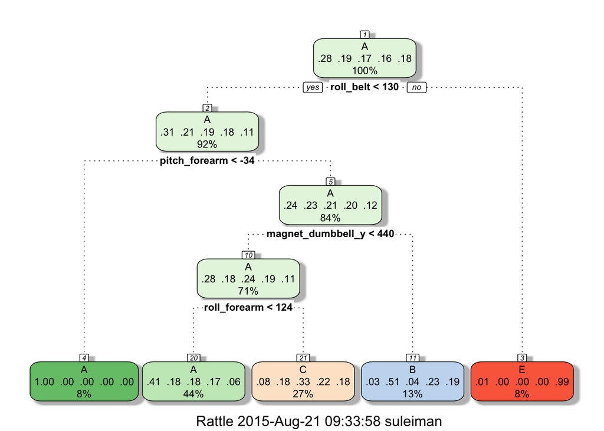

## Predictor correlation evaluation

We notice that several of the predictor variables are highly correlated suggesting that me might want to preprocess a model with principal components analysis for variable reduction.

```r
# note the classe is the last column
M <- abs(cor(training[,-53]))
diag(M) <- 0
which(M > 0.8, arr.ind=T)
```

```
##                  row col
## yaw_belt           3   1
## total_accel_belt   4   1
## accel_belt_y       9   1
## accel_belt_z      10   1
## accel_belt_x       8   2
## magnet_belt_x     11   2
## roll_belt          1   3
## roll_belt          1   4
## accel_belt_y       9   4
## accel_belt_z      10   4
## pitch_belt         2   8
## magnet_belt_x     11   8
## roll_belt          1   9
## total_accel_belt   4   9
## accel_belt_z      10   9
## roll_belt          1  10
## total_accel_belt   4  10
## accel_belt_y       9  10
## pitch_belt         2  11
## accel_belt_x       8  11
## gyros_arm_y       19  18
## gyros_arm_x       18  19
## magnet_arm_x      24  21
## accel_arm_x       21  24
## magnet_arm_z      26  25
## magnet_arm_y      25  26
## accel_dumbbell_x  34  28
## accel_dumbbell_z  36  29
## gyros_dumbbell_z  33  31
## gyros_forearm_z   46  31
## gyros_dumbbell_x  31  33
## gyros_forearm_z   46  33
## pitch_dumbbell    28  34
## yaw_dumbbell      29  36
## gyros_forearm_z   46  45
## gyros_dumbbell_x  31  46
## gyros_dumbbell_z  33  46
## gyros_forearm_y   45  46
```

## Model 2 - Random forest with principal components

Model two supports the lecture that asserted that random forest was typically a higher accuracy algorithm. We can see from our output that the accuracy level of 0.978 is quite high.

```r
modelFit2 <- train(training$classe ~ ., method="rf", preProcess="pca", data=training, allowParallel = TRUE)
confusionMatrix(testing$classe, predict(modelFit2, testing))
```

```
## Confusion Matrix and Statistics
##
##           Reference
## Prediction    A    B    C    D    E
##          A 1390    2    2    1    0
##          B   17  925    6    0    1
##          C    1   18  827    8    1
##          D    2    2   27  772    1
##          E    0    3    6   10  882
##
## Overall Statistics
##
##                Accuracy : 0.978
##                  95% CI : (0.9735, 0.9819)
##     No Information Rate : 0.2875
##     P-Value [Acc > NIR] : < 2.2e-16
##
##                   Kappa : 0.9721
##  Mcnemar's Test P-Value : NA
##
## Statistics by Class:
##
##                      Class: A Class: B Class: C Class: D Class: E
## Sensitivity            0.9858   0.9737   0.9528   0.9760   0.9966
## Specificity            0.9986   0.9939   0.9931   0.9922   0.9953
## Pos Pred Value         0.9964   0.9747   0.9673   0.9602   0.9789
## Neg Pred Value         0.9943   0.9937   0.9899   0.9954   0.9993
## Prevalence             0.2875   0.1937   0.1770   0.1613   0.1805
## Detection Rate         0.2834   0.1886   0.1686   0.1574   0.1799
## Detection Prevalence   0.2845   0.1935   0.1743   0.1639   0.1837
## Balanced Accuracy      0.9922   0.9838   0.9729   0.9841   0.9959
```

## Model 3 - Random forest with 10-fold cross validation without PCA

Finally, we see that PCA preprocessing contributes to a slight loss of accuracy (from 0.978 to 0.9943). I also decreased to a 10-fold cross validated model from the default of 25 to save processing time (these were taking forever to run).

```r
modelFit3 <- train(training$classe ~ ., method="rf", data=training, allowParallel = TRUE,
                   trControl = trainControl(method = "cv", number = 10))
confusionMatrix(testing$classe, predict(modelFit3, testing))
```

```
## Confusion Matrix and Statistics
##
##           Reference
## Prediction    A    B    C    D    E
##          A 1395    0    0    0    0
##          B    7  939    3    0    0
##          C    0    6  847    2    0
##          D    0    1    8  794    1
##          E    0    0    0    0  901
##
## Overall Statistics
##
##                Accuracy : 0.9943
##                  95% CI : (0.9918, 0.9962)
##     No Information Rate : 0.2859
##     P-Value [Acc > NIR] : < 2.2e-16
##
##                   Kappa : 0.9928
##  Mcnemar's Test P-Value : NA
##
## Statistics by Class:
##
##                      Class: A Class: B Class: C Class: D Class: E
## Sensitivity            0.9950   0.9926   0.9872   0.9975   0.9989
## Specificity            1.0000   0.9975   0.9980   0.9976   1.0000
## Pos Pred Value         1.0000   0.9895   0.9906   0.9876   1.0000
## Neg Pred Value         0.9980   0.9982   0.9973   0.9995   0.9998
## Prevalence             0.2859   0.1929   0.1750   0.1623   0.1839
## Detection Rate         0.2845   0.1915   0.1727   0.1619   0.1837
## Detection Prevalence   0.2845   0.1935   0.1743   0.1639   0.1837
## Balanced Accuracy      0.9975   0.9950   0.9926   0.9975   0.9994
```

Model 3 was chosen as our final model since it had the lowest out of sample error. A chart of variable importance for prediction (most to least) is shown below.

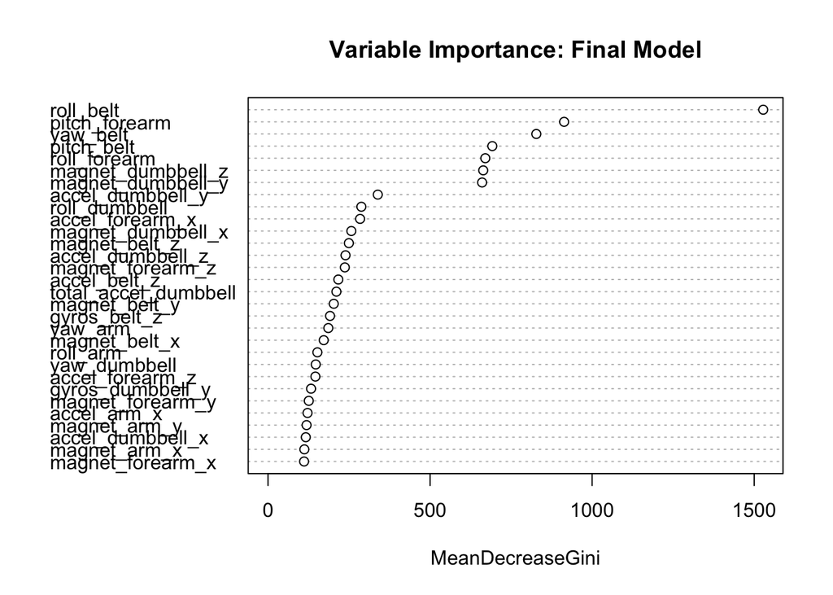

## Prediction - test cases

Finally, we use model 3 to predict our 20 test cases.

```r
pred_test <- predict(modelFit3, test)
pred_test
```

```
##  [1] B A B A A E D B A A B C B A E E A B B B
## Levels: A B C D E
```